# Practical Machine Learning Project

Deniz D.

2023-12-01

## Overview

This report is for the Practical Machine Learning course final project.

In this project we use data that was collected during exercise using wearable devices to predict how well the exercise was performed.

The training data for this project are available here: https://d396qusza40orc.cloudfront.net/predmachlearn/pml-training.csv

The test data are available here: https://d396qusza40orc.cloudfront.net/predmachlearn/pml-testing.csv

The data for this project come from this (now defunct) source: http://groupware.les.inf.puc-rio.br/har

The variable **classe** in the training set indicates the manner the exercise was performed in.

## Loading Data

First we load the necessary libraries, set the seed and read in the data.

```r
library(caret)
library(rattle)
library(randomForest)
set.seed(1234)
```

```r
traincsv <- read.csv("pml-training.csv", header = TRUE, na.strings=c("NA","#DIV/0!",""))
testcsv <- read.csv("pml-testing.csv", header = TRUE, na.strings=c("NA","#DIV/0!",""))
dim(traincsv)
```

```
## [1] 19622   160
```

```r
dim(testcsv)
```

```
## [1]  20 160
```

## Clean Up

There are many NA values in the training set. To clean up data, we start by removing variables with mostly (> %75) NA values. We also remove the first 7 columns which are not predictors.

```r
traincsv <- traincsv[,colMeans(is.na(traincsv)) < .75]
traincsv <- traincsv[,-c(1:7)]
dim(traincsv)
```

```
## [1] 19622    53
```

## Random Sub Sampling

We set aside some data for validation (%70 for training, %30 for validation)

```r
inTrain <- createDataPartition(y=traincsv$classe, p=0.7, list=FALSE)
train <- traincsv[inTrain, ]
valid <- traincsv[-inTrain, ]
```

## Prediction Models

We are going to try three models, Decision Tree, Random Forest and Boosting

## Decision Tree

Fitting a decision tree model and plot.

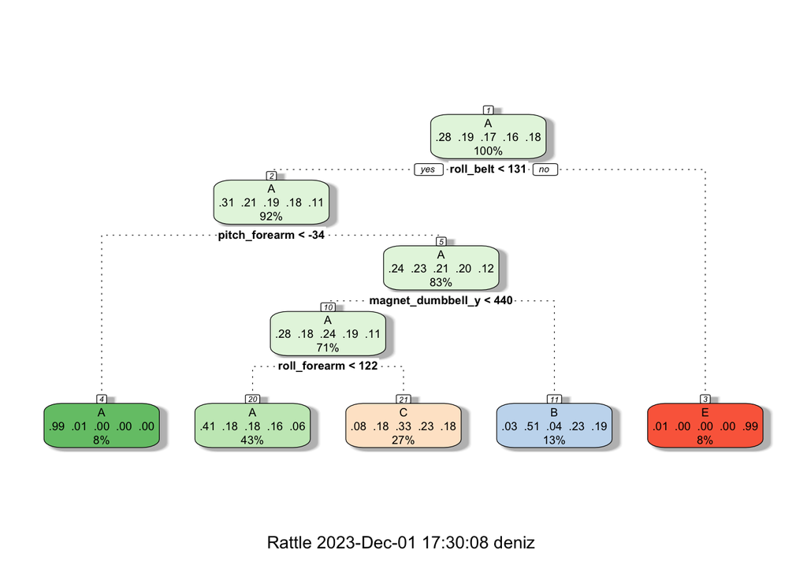

```r
modTREE <- train(classe~., data = train, method= "rpart")
fancyRpartPlot(modTREE$finalModel)
```

Prediction with decision tree.

```r
predTREE <- predict(modTREE, valid)
confTREE <- confusionMatrix(predTREE, as.factor(valid$classe))
confTREE
```

```
## Confusion Matrix and Statistics
##
##           Reference
## Prediction    A    B    C    D    E
##          A 1519  473  484  451  156
##          B   28  401   45  167  148
##          C  123  265  497  346  289
##          D    0    0    0    0    0
##          E    4    0    0    0  489
##
## Overall Statistics
##
##                Accuracy : 0.4938
##                  95% CI : (0.4809, 0.5067)
##     No Information Rate : 0.2845
##     P-Value [Acc > NIR] : < 2.2e-16
##
##                   Kappa : 0.338
##
##  Mcnemar's Test P-Value : NA
##
## Statistics by Class:
##
##                      Class: A Class: B Class: C Class: D Class: E
## Sensitivity            0.9074  0.35206  0.48441   0.0000  0.45194
## Specificity            0.6286  0.91825  0.78946   1.0000  0.99917
## Pos Pred Value         0.4927  0.50824  0.32697      NaN  0.99189
## Neg Pred Value         0.9447  0.85518  0.87881   0.8362  0.89002
## Prevalence             0.2845  0.19354  0.17434   0.1638  0.18386
## Detection Rate         0.2581  0.06814  0.08445   0.0000  0.08309
## Detection Prevalence   0.5239  0.13407  0.25828   0.0000  0.08377
## Balanced Accuracy      0.7680  0.63516  0.63693   0.5000  0.72555
```

Confusion matrix shows a low accuracy and the matrix itself shows high error.

## Random Forest

Next we are fitting a Random Forest model and predict based on that.

```r
modRF <- randomForest(as.factor(classe) ~ ., data = train, na.action = na.omit)
predRF <- predict(modRF, valid)
confRF <- confusionMatrix(predRF, as.factor(valid$classe))
confRF
```

```
## Confusion Matrix and Statistics
##
##           Reference
## Prediction    A    B    C    D    E
##          A 1673    1    0    0    0
##          B    1 1135   12    0    0
##          C    0    3 1014    7    0
##          D    0    0    0  956    0
##          E    0    0    0    1 1082
##
## Overall Statistics
##
##                Accuracy : 0.9958
##                  95% CI : (0.9937, 0.9972)
##     No Information Rate : 0.2845
##     P-Value [Acc > NIR] : < 2.2e-16
##
##                   Kappa : 0.9946
##
##  Mcnemar's Test P-Value : NA
##
## Statistics by Class:
##
##                      Class: A Class: B Class: C Class: D Class: E
## Sensitivity            0.9994   0.9965   0.9883   0.9917   1.0000
## Specificity            0.9998   0.9973   0.9979   1.0000   0.9998
## Pos Pred Value         0.9994   0.9887   0.9902   1.0000   0.9991
## Neg Pred Value         0.9998   0.9992   0.9975   0.9984   1.0000
## Prevalence             0.2845   0.1935   0.1743   0.1638   0.1839
## Detection Rate         0.2843   0.1929   0.1723   0.1624   0.1839
## Detection Prevalence   0.2845   0.1951   0.1740   0.1624   0.1840
## Balanced Accuracy      0.9996   0.9969   0.9931   0.9959   0.9999
```

Accuracy here is very high and vast majority of data is on the diagonal (correct) with very few errors.

## Boosting

Here, we are fitting a Gradient Boosted Tree model and predict.

```r
modGBM <- train(classe~., data=train, method = "gbm", trControl = trainControl(number=3), verbose = FALSE)
predGBM = predict(modGBM, valid)
confGBM <- confusionMatrix(predGBM, as.factor(valid$classe))
confGBM
```

```
## Confusion Matrix and Statistics
##
##           Reference
## Prediction    A    B    C    D    E
##          A 1654   29    0    3    1
##          B   11 1078   38    3    9
##          C    6   32  977   26    8
##          D    3    0   11  927   10
##          E    0    0    0    5 1054
##
## Overall Statistics
##
##                Accuracy : 0.9669
##                  95% CI : (0.962, 0.9713)
##     No Information Rate : 0.2845
##     P-Value [Acc > NIR] : < 2.2e-16
##
##                   Kappa : 0.9581
##
##  Mcnemar's Test P-Value : 4.284e-06
##
## Statistics by Class:
##
##                      Class: A Class: B Class: C Class: D Class: E
## Sensitivity            0.9881   0.9464   0.9522   0.9616   0.9741
## Specificity            0.9922   0.9871   0.9852   0.9951   0.9990
## Pos Pred Value         0.9804   0.9464   0.9314   0.9748   0.9953
## Neg Pred Value         0.9952   0.9871   0.9899   0.9925   0.9942
## Prevalence             0.2845   0.1935   0.1743   0.1638   0.1839
## Detection Rate         0.2811   0.1832   0.1660   0.1575   0.1791
## Detection Prevalence   0.2867   0.1935   0.1782   0.1616   0.1799
## Balanced Accuracy      0.9901   0.9668   0.9687   0.9784   0.9865
```

Here the accuracy is high, but not as high as Random Forest. Again vast majority of data is on the diagonal, showing correct prediction, with few errors.

## Conclusion and Predictions on the Test Set

Random Forest has the best accuracy on the validation set, as can be seen below.

```r
rbind("Tree" = confTREE$overall[1],
      "Random Forest" = confRF$overall[1],
      "GBM" = confGBM$overall[1])
```

```
##                Accuracy
## Tree          0.4937978
## Random Forest 0.9957519
## GBM           0.9668649
```

So we will continue with our random forest model to predict on the Test Set.

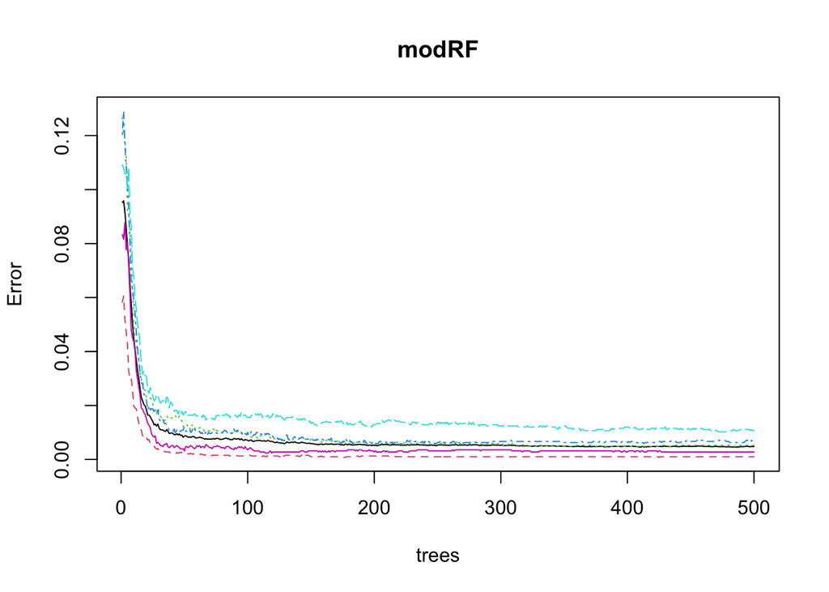

```r
plot(modRF)
```

```r
predict(modRF, testcsv)
```

```
##  1  2  3  4  5  6  7  8  9 10 11 12 13 14 15 16 17 18 19 20
##  B  A  B  A  A  E  D  B  A  A  B  C  B  A  E  E  A  B  B  B
## Levels: A B C D E
```